# R Notebook - scraping in R

## R Notebook

This is an R notebook, which mixes your notes, your code and the results of your code. When you see a grey area, it’s called a “chunk”. To run it, put your cursor anywhere in that area and hit CMD-SHFT-Enter.

Below each chunk are the results of the most recent time it was run. If you are working on it on your own computer, you’ll want to clear the output, or re-run each chunk. (Clear the output by selecting “Clear all Output” under the Edit menu or through the little gear dropdown at the top of the file. )

R Notebooks are written in a language called Markdown, which is easy to convert to a formatted web page without much coding.

```r
library(tidyverse)   #for everything!
library(readr)       #for good reading of tsv
library(rvest)       #this is to read the html files.
```

## Scraping strategy

I often do scraping in three steps. People who are real computer programmers know how to efficiently combine them, but I don’t. I do this to avoid overloadinging a site or repeating the most basic but most perilous step of grabbing pages from a site.

1. Get a list of pages to scrape by their web address. Sometimes you can get a full list but have to click into each page for details, which is what we’ll do here. Sometimes you can use your XML Miracle to get each link. Sometimes you have to go through all the pages of a search result, or programmatically fill out a form to get every possible list.
2. Go through that list and download each page, checking to make sure you don’t already have it and that it worked. (We’re going to skip the checking part here.) When I was scraping the New York City’s construction inspection site, about one of every five pages failed. I had to find a way to tell which ones, then create lists to double back on.
3. Pull data out of each page, putting it into a data frame or several data frames linked by a common variable. This can be simple or it can be difficult, but what you learned in your [Scraping 101](https://cronkitedata.github.io/reporting/tutorials/scrape-simple/) section about the Chrome Scraper about the Document Object Model and XPATH is used here as well.

## Getting the list of pages

First, I went to the [Maricopa Sheriff Office’s website](https://www.mcso.org/Mugshot) to look at mugshots. I used the trick we used before to increase the number of lines shown to all of the ones that are avaialable (changing “100” to “500” in the select box).

Then I used Chrome Scraper to pick up all of these rows into a table, changing the first column from the word “Picture” to the link that underlies it. (I copied the results to the clipboard, opened a text editor like Notepad and saved it. The clipboard uses tab-separated values.)

[figure not shown]

### Read the table into R

Now I want to read that table into R:

```r
mug_list <-
    read_tsv("rstats-mugshots.txt")
```

I don’t like these names – they’ll be too hard to deal with so let’s change them.

```r
col_names <- c("url", "bookingid", "fname", "lname", "dob_txt", "crime", "booking_dt_txt")

colnames (mug_list) <- col_names

#let's see what it's called now:
head(mug_list)
```

| url | bookingid | fname | lname | dob_txt | crime | booking_dt_txt |
| --- | --- | --- | --- | --- | --- | --- |
| /Mugshot/GetMugshotDetails?bookingNumber=T503861 | T503861 | AARON | SMITH | 3/20/1988 | Drug Offenses | 11/6/2018 |
| /Mugshot/GetMugshotDetails?bookingNumber=T504137 | T504137 | ABIGAYLE | STROM | 8/23/1991 | Drug Offenses | 11/7/2018 |
| /Mugshot/GetMugshotDetails?bookingNumber=T503776 | T503776 | ADEENNA | OSWALD | 9/19/1968 | Offenses against Public Order | 11/6/2018 |
| /Mugshot/GetMugshotDetails?bookingNumber=T504068 | T504068 | ADOLFO | BAHENA | 4/11/2000 | Drug Offenses | 11/7/2018 |
| /Mugshot/GetMugshotDetails?bookingNumber=T503926 | T503926 | ADRIAN | GARZA | 11/13/1984 | Criminal Trespass and Burglary | 11/6/2018 |
| /Mugshot/GetMugshotDetails?bookingNumber=T503953 | T503953 | ADRIANE | GARY | 5/25/1989 | Theft | 11/6/2018 |

## Get the details for each inmate

I want to go through the whole file, then usie the *bookingid* variable to create a web URL and save the page.

### Test yourself on just one

It’s usually a good idea to see if you can program downloading just one page before you start trying a bunch of them. By looking at the url’s in the mug_list data frame, I could see that all of them start with the same thing:

```
/Mugshot/GetMugshotDetails?bookingNumber=
```

When you see something start with / in a web address, it means it goes back to the site’s root, so it must start with:

```
https://www.mcso.org
```

So putting it together, we can make a variable with the part that never changes, then stick in the booking ID from our list.

There are a few things going on in here.

I have to tell the computer where to get a page and where to save it, but I want to do it so that I don’t have to know in advance what the ID is.

First, you’ll assign some text to a variable. This is called a *literal*, which just means “take this literally, as well as seriously.”

Second, you need to create a dynamic way to name the files you plan to save. I created a folder called *mugs* within my default directory, and I plan to use the inmate ID + .html to name the new files.

Third, you need to tell the program where to get the page. It uses the same inmate ID, but it tacks that onto the the URI, which we filled up with the literal text that we need to use.

There are also a couple of functions you may not have seen:

```
str_trim: get rid of leading and trailing spaces, including hidden characters like tabs and carriage returns.
```

If you get an error with str_trim, make sure you’ve loaded library(stringr)

```
paste(str1, str2, str3, ... sep="") : concatenate some strings together, but don't separate them by anything. The default would be to separate with a blank, which we don't want. The strings can either be literals or variables that hold strings.
```

THe *download* command is part of the package called *rvest*, which is loaded above. It’s R’s most common package used for scraping, built by our hero Hadley Wickham.

*CAUTION: IF SOMEONE HAS LEFT THE JAIL AFTER YOU DOWNLOADED THE LIST, YOU’LL GET AN ERROR PAGE. DON’T RUN THIS YOURSELF ON THIS LIST OF ID’S !!*

```r
#every mugshot's URL begins this way:
URI <- "https://www.mcso.org/Mugshot/GetMugshotDetails?bookingNumber="


#take the first row, second column and remove any extra spaces using the tidyverse's str_trim. Be sure you've loaded the tidyverse and stringr in your library() statements if you get a "str_trim not found" error.

my_id <- str_trim ( mug_list[1,2] )  #depends on tidyverse
my_id


# paste ( string1, string2, .... stringn, sep="") concatenates all of the strings, with nothing
# between them. Se need the sep="" because usually there is a space between each of them.
# You can use *literal strings*, or things in quotes, or *variables* that contain strings.
#

#this is the name of the file that I want to save on my computer.
#It's in a subfolder I've already created called
my_file <- paste ("mugs/", my_id, ".html", sep="")
my_file

my_url <- paste(URI, mug_list[1, 2], sep="" )
my_url

#now download it to my url. This isn't the best way to do this, because you don't know what the response code was, but we'll do it for # now.
download.file(my_url, my_file, method="libcurl")
```

[output not shown]

### Create a loop to get them all

It worked! THere is a file inside my “mugs” directory that has the HTML behind one inmate’s detail page.

We’re going to use what’s called a loop to get several of the pages. (I’m not going to do all 481 because this is just an example ) . I want a list of ids (column 2 ) taken from the first five rows (1:5)

```r
my_ids <- mug_list[1:5, 2]
```

Now we’re just going to walk through each one, and do exactly what we did before. The only difference is that we have to substitute the inmate ID we used earlier with a dynamically created variable, which gets made when we ask R to do the same thing for a list of items,

This says, do the same thing for every item in my_urls, and temporarily call each one *id* until I’m done with it. It’s often a good idea to put in a tiny wait period between items in your loop to avoid overloading the web site. One second is a lot, but hey – the computer’s doing the work, so what do you care?

```r
for (id in my_ids) {
  id <- str_trim(id)
  my_file <- paste ("mugs/", id, ".html", sep="")
  my_url <- paste(URI, id, sep="" )

  download.file(my_url, my_file, method="libcurl")

  #now wait for one second before I go any further.
  Sys.sleep(1)

}
```

Now, we have the first five pages saved on our computer, so we don’t need to bother the sheriff anymore.

## Convert the pages to data

The next step is to convert each page to a row in a new data frame that can be linked back to the original list with more details.

Here’s what a page looks like:

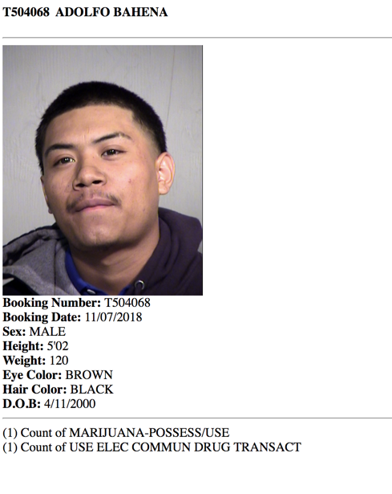

But underneath, there is HTML:

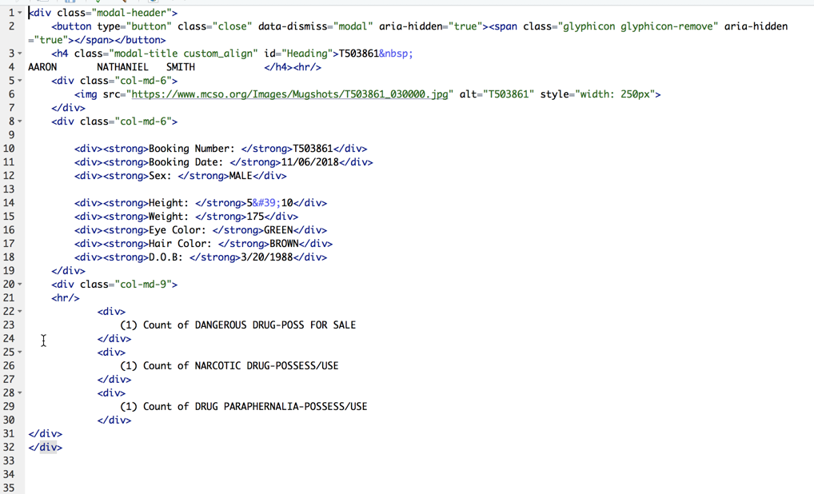

This is where our old friend XPATH comes in as well as the R package called rvest(). (We loaded it in the library earlier.)

### Try one first

Again, let’s just try one at a time, then we can make a loop to go through them all:

```r
my_html <- read_html("mugs/T504068.html")

#I peeked, and know that everything I care about is in a <div> tag. This command will get every div tag, even if they are at a different level than one another.

nodes <- html_nodes(my_html, xpath="//div")
nodes
```

```
## {xml_nodeset (14)}
##  [1] <div class="modal-header">\r\n    <button type="button" class="clos ...
##  [2] <div class="col-md-6">\r\n        <img src="https://www.mcso.org/Im ...
##  [3] <div class="col-md-6">\r\n\r\n        <div>\n<strong>Booking Number ...
##  [4] <div>\n<strong>Booking Number: </strong>T504068</div>
##  [5] <div>\n<strong>Booking Date: </strong>11/07/2018</div>
##  [6] <div>\n<strong>Sex: </strong>MALE</div>
##  [7] <div>\n<strong>Height: </strong>5'02</div>
##  [8] <div>\n<strong>Weight: </strong>120</div>
##  [9] <div>\n<strong>Eye Color: </strong>BROWN</div>
## [10] <div>\n<strong>Hair Color: </strong>BLACK</div>
## [11] <div>\n<strong>D.O.B: </strong>4/11/2000</div>
## [12] <div class="col-md-9">\r\n    <hr>\n<div>\r\n\r\n\r\n               ...
## [13] <div>\r\n\r\n\r\n                (1) Count of MARIJUANA-POSSESS/USE ...
## [14] <div>\r\n\r\n\r\n                (1) Count of USE ELEC COMMUN DRUG  ...
```

```r
#Look at the 7th line in the output: this is <div>\n<strong>Height: </strong>5'02</div>  We want just the 5'02 part.
#this is just an example of how intricate xpath can be.
#it only works if you tack on the html_text() function at the end.

#the xpath command took a little finagling. this says, take the first thing below the 7th div tag,
#then take the thing that sits next to it before the ending div tag,
#then turn whatever you find into text.


height <- html_nodes(nodes[7], xpath="*[1]/following-sibling::text()") %>%
          html_text()
sex <- html_nodes(nodes[6], xpath="*[1]/following-sibling::text()") %>%
          html_text()
eye_color <- html_nodes(nodes[9], xpath="*[1]/following-sibling::text()") %>%
          html_text()

#create a row worth of data, making sure we have a data
row <- c("T504068", height, sex, eye_color)
row
```

```
## [1] "T504068" "5'02"    "MALE"    "BROWN"
```

#### The specific charges

The next part is a little trickier, because there could be a list of charges. You’d have to decide what you want to do with them. The choices could be:

- Take the first one, presumably the lead, or most serious, charge.
- Smush them all into one variable, perhaps separated by a semicolon or something.
- Create another table of information at a different unit of analysis.

```r
charge_nodes <- html_nodes(my_html, xpath =  "//div[@class='col-md-9']/div")
charge_nodes
```

```
## {xml_nodeset (2)}
## [1] <div>\r\n\r\n\r\n                (1) Count of MARIJUANA-POSSESS/USE  ...
## [2] <div>\r\n\r\n\r\n                (1) Count of USE ELEC COMMUN DRUG T ...
```

```r
charges = as.character("")

for (n in charge_nodes) {
  node_text <- html_text(n, trim=TRUE)
  paste( charges, node_text, sep="; ")
}


charges
```

```
## [1] ""
```

Later, you can put this all together in a loop.